# NeuroFlow Data Analyst Exercise

```python
import IPython.core.display as di

# This line will hide code by default when the notebook is exported as HTML
di.display_html(
    '<script>jQuery(function() {if (jQuery("body.notebook_app").length == 0) { jQuery(".input_area, .output_stderr").toggle(); jQuery(".prompt").toggle();}});</script>', raw=True)

CSS = """.input_area .output_stderr {height: 2.0em; overflow: hidden}"""
```

### Approach to Designing Visualization:

My approach to visualization starts with identifying the audience, purpose, and available data. I pick a visualization method that is suited to these three things. Instead of making assumptions about how the audience would use the visualization in various circumstances, I chose to make a solution that was flexible on key design parameters. If I were developing this visualization for NeuroFlow, I would gather information on user preferences by observing behavior.

#### Audience of Visualization:

- Patients
- Care providors

#### Purpose of Visualization:

- Show progress on the four subjective measures over time.
- Provide data to patients and care-providers that can be the basis of conversations.

#### Selected Visualization Method:

Based on this information, I chose to make a line graph with a measure of time on the x-axis and scores for the measures on the y-axis.

My visualization provides flexibility to answer a couple questions on design:

- Do users want to see all visualizations of measures at once or individually? The user can choose which measures to focus on. If multiple measures are selected, they appear on the same graph.
- What time-period for summarizing measures do users prefer? Daily, weekly, semi-monthly, monthly?

Below are examples of the visualizations produced by my approach:

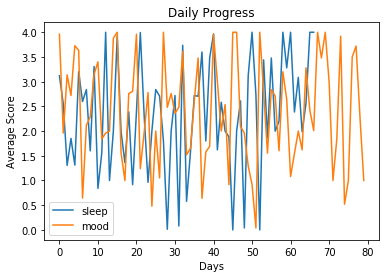

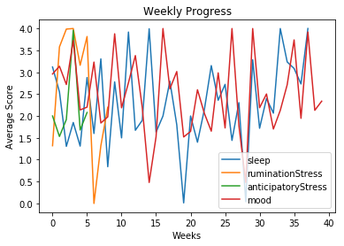

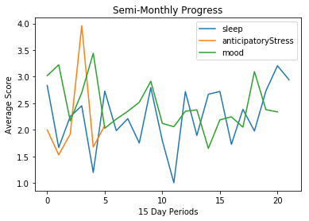

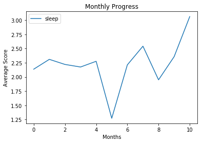

```python
#Libraries
import pandas as pd
import matplotlib.pyplot as plt
import datetime
import numpy as np

# Subjective Measures Dataset
Measures = pd.read_csv('C:/Users/bsalv/OneDrive/Documents/Job Application Materials/Neuroflow/Data Analyst Exercise/subj_measures.csv')

#### Cleaning Subjective Measures Dataset ####
# Converting Date to Date-Time
Measures['date'] = pd.to_datetime(Measures['date'])
# Checking data types for other columns
# Checking for missing data.

#### Visualizations ####
## Figure 1: Daily - single measure
questionlist = ['sleep', 'mood']

UserData = Measures.drop(Measures[(Measures['user_id'] != 1074)].index)
UserData['DateDaily'] = UserData['date'] - pd.to_timedelta(1, unit='d')
UserData = UserData.groupby(['type', pd.Grouper(key='DateDaily', freq='D')])['value'].mean().reset_index().sort_values('DateDaily')

plt.figure(1)
for question in questionlist:
    Temp = UserData.drop(UserData[(UserData['type'] != question)].index)
    Temp = Temp.reset_index(drop=True)
    Progress = plt.plot(Temp.index.values , Temp['value'], label = question)

plt.legend()
plt.title('Daily Progress')
plt.xlabel('Days')
plt.ylabel('Average Score')
plt.show()

## Figure Weekly - all measures
questionlist = ['sleep', 'ruminationStress', 'anticipatoryStress', 'mood']
plt.figure(2)

UserData = Measures.drop(Measures[(Measures['user_id'] != 1074)].index)
UserData['DateGroup'] = UserData['date'] - pd.to_timedelta(7, unit='d')
UserData = UserData.groupby(['type', pd.Grouper(key='DateGroup', freq='W')])['value'].mean().reset_index().sort_values('DateGroup')

for question in questionlist:
    Temp = UserData.drop(UserData[(UserData['type'] != question)].index)
    Temp = Temp.reset_index(drop=True)
    Progress = plt.plot(Temp.index.values , Temp['value'], label = question)

plt.legend()
plt.title('Weekly Progress')
plt.xlabel('Weeks')
plt.ylabel('Average Score')
plt.show()

## Semi-monthly - three measures
questionlist = ['sleep', 'anticipatoryStress', 'mood']
plt.figure(3)

UserData = Measures.drop(Measures[(Measures['user_id'] != 1074)].index)
UserData['DateGroup'] = UserData['date'] - pd.to_timedelta(15, unit='d')
UserData = UserData.groupby(['type', pd.Grouper(key='DateGroup', freq='SM')])['value'].mean().reset_index().sort_values('DateGroup')

for question in questionlist:
    Temp = UserData.drop(UserData[(UserData['type'] != question)].index)
    Temp = Temp.reset_index(drop=True)
    Progress = plt.plot(Temp.index.values , Temp['value'], label = question)

plt.legend()
plt.title('Semi-Monthly Progress')
plt.xlabel('15 Day Periods')
plt.ylabel('Average Score')
plt.show()

## Monthly - one measure
questionlist = ['sleep']
plt.figure(4)

UserData = Measures.drop(Measures[(Measures['user_id'] != 1074)].index)
UserData['DateGroup'] = UserData['date'] - pd.to_timedelta(30, unit='d')
UserData = UserData.groupby(['type', pd.Grouper(key='DateGroup', freq='M')])['value'].mean().reset_index().sort_values('DateGroup')

for question in questionlist:
    Temp = UserData.drop(UserData[(UserData['type'] != question)].index)
    Temp = Temp.reset_index(drop=True)
    Progress = plt.plot(Temp.index.values , Temp['value'], label = question)

plt.legend()
plt.title('Monthly Progress')
plt.xlabel('Months')
plt.ylabel('Average Score')
plt.show()

# Problems:
    # 2. How to clean up the axis based on the time scale they chose - use the date parsing - example for biweekly what does 20 mean.
    # 3. is it possible to look at line of best fit - only if you are looking at variables one at a time.

# List of unanswered questions that I would want to research more and talk to user design about:
    # 1. How do people and psychiatrists use the graphs what do they want to highlight - is it week to week jumps, is it daily?
    # 2. Do people review this data on a daily, weekly or monthly time frame and should they be able to pick?
    # 3. Document the sylistic iterations that I looked at.
    # 4. Testing whether there is a significant cost to simplicity of user interface or processesing on our end to keep this flexibility.
        # Example we could look at whether peolpe and their health care providers choose different scales or do they stick to one throughout.
    # 5. Stacked graphs, versus seperate versus average and how to build that functionality in the code.
    # If an how are actual dates used - example if its used in the present to diagnose what caused a particular movement then only the present position is useful
        #but it could help if you are meeting once a month to be able to ask what happened then.
        # brainstorm other options like superiposing different timescales.
# Plotting histogram of engagement - vast majority are between 290 and under 1 year. None below 220 days!
# DurationEngagement = plt.hist(UsersTime['duration'])
# Does frequency of measures per week decrease over time? - Not sure how useful this one is.
# Do we generally see an increase or decrease over time and on what time frame? - Not sure how useful this one is either.
#- Number of data points per week - what is typical.
# Missing data - are some questions left unanswered.
# Are there ways to categorize the respondents according to this data which may help add more flexiblity
# in the visualization that is appropriate for them?  Or do they all roughly behave the same.
```

### Learnings from Visualizations:

Reducing Noise vs. Update Frequency: As we move from daily to weekly to semi-monthly to monthly we see that variance reduces because each point on the graph is an average. That is in the monthly graph the lowest point is 1.25 and the highest is 3 whereas in the weekly graph the lowest is 0 and highest is 4. That is also why it is hard to make out any trends in the daily graph but it is much easier to see one in the semi-monthly and monthly graphs. However if a care providor is frequently checking on a patient in crisis or a new patient they may want to see more frequent updates so that they can offer timely support. In this case the flexibility to see both would be useful. Please note that in this case I would probably change the daily graph to be a scatter plot and I would adjust the x-axis to be actual dates so that we can see dates with no submitted measurements. In this dataset where all patients have been sending data for over 200 days (time between first and last measurement) it seems that the semi-monthly and monthly work well.

Incomplete Submissions: People are not submitting responses for all of the questions with the same consistency. This suggests that we need to understand more about why users respond more consistently to some questions than others and how this bias and lack of data might affect if and how we can visualize the data - more on that below. In addition, this means that we need to figure out how to show continuty even when there are periods with missing data without interpolating!

### Follow-Up Research:

There is a lot more that can be studied and observed to improve on this visualization. To give structure to this investigation, I have identified two broad areas that I think are very important to focus on. For each area, I give some thoughts on why this is important in this context and a way to analyze data to make decisions on the visualization design.

#### 1. How do we summarize data to give an accurate and useful sense of progress given that these measures are subjective and self-reported?

The accuracy of any visualization depends on inherent variation in the measure and on typical user behavior.

Inherent variation in measure: For example, users will probably only respond to the quality of sleep question once per day. However, mood and measures of stress may be recorded multiple times in the day and scores can vary a lot within a day. With mood, and stress we are more likely to see user behavior have a large impact on the quality of data that is collected.  
User behavior: Below, I go into a couple of examples of how user behavior could affect how to use data from measurements by identifying some possible user "types":

- State independent: If a user answers all their questions regularly regardless of changes in their mood and stress, then I would argue it would be effective to weight each observation in a time-period roughly equally by using a measure.
- Response bias: For example, if a respondent is more likely to submit data when they experience a negative movement in a measure over a positive movement or vice-versa, then each data point cannot be equally weighted. Bias affects data quality, which affects the accuracy and usefulness of any visualization.

If given more time, I would propose performing a cluster analysis to investigate whether these issues are appearing in the data by attempting to see how users fall into four possible combinations regularity and variance of response within a time-period. I believe that people falling into low variance and low regularity cluster might be the most likely to have response bias. It is unclear how we could improve the visualization itself with this information. Perhaps we offer another visualization that only uses data that is unlikely to be biased like the 8 AM measurement. All other measurements can still be important to capture so they can guide discussions but may not be useful for showing long-term progress. If bias is a big problem, we could also offer guidance on interpreting the visualizations and stress the importance of submitting consistent responses for data quality.

Regularity of Response:

- High Regularity - Low variance in the number of observations per time-period.
- Low Regularity - High variance in the number of observations per time-period.

Variance in Average Response:

- High Variance - High variance of responses within the time-period.
- Low Variance - Low variance of responses within the time-period.

#### 2. How does user behavior change over time?

I have already mentioned that care providers may be more interested in updates rather than progress at the beginning of treatment or when the patient is going through an especially hard period. The opposite might be true later in treatment or when the patient has reached a better equilibrium. We should investigate whether care providers use the data differently when they have a new or old client. Also, motivation to answer questions can change over time, which could result in biased data measurements. For example, we can see that the user from the example visualizations stopped submitting data on anticipatory stress quite early on. To investigate, we could look at the change in measurement frequency over time.